# My Capstone Project

Author

Affiliation

Benedict Addae-Mensah

[KNUST](https://www.knust.edu.gh/)

Published

June 20, 2024

# 1. Introduction

## 1.1. Background

Groundwater, a vital component of Earth’s hydrological cycle, plays a pivotal role in sustaining human societies, particularly in regions where surface water sources are scarce or unreliable. The study focuses on the Greater Accra and Ashanti regions of Ghana, where systematic borehole data collection provides a unique opportunity to delve into the hydrogeological complexities shaping water availability. The significance of groundwater in supporting domestic, agricultural, and industrial needs underscores the importance of understanding its dynamics for informed decision-making.

## 1.2. Problem Statement

The Greater Accra and Ashanti regions of Ghana face a multifaceted challenge in sustainable water resource management characterized by an inadequate understanding of aquifer characteristics, limited insight into temporal variations in groundwater levels, an unexplored influence of aquifer material on hydrogeological parameters, a lack of evidence-based decision support, and persistent challenges in community water access. This collective deficiency underscores a critical gap in knowledge, hindering effective policies and strategies for preserving and managing groundwater resources. Consequently, a comprehensive study is imperative to address these knowledge gaps and provide essential insights for informed decision-making, ensuring the sustainable utilization and conservation of groundwater in these regions.

## 1.3. Objectives

- To systematically analyze borehole data to comprehensively understand the characteristics of aquifers in the Greater Accra and Ashanti regions of Ghana, including depth, static water level, and geological composition.
- To investigate seasonal fluctuations and long-term trends in groundwater levels over the specified time period to enhance our understanding of temporal dynamics.
- To evaluate the impact of different aquifer materials, such as Schist and Gneiss, on hydrogeological parameters, including transmissivity and specific capacity.
- To generate a robust dataset and conduct thorough analyses to offer evidence-based insights that can inform decision-makers, policymakers, and water resource managers in the development of effective strategies for sustainable water resource management.

## 1.4. Scope and Significance

The project, which encompasses communities within the Greater Accra and Ashanti regions of Ghana, ensures a diverse representation of hydrogeological conditions. The insights gained from this study extend beyond academic realms, holding practical implications for community water access, infrastructure development, and regional water resource planning. The significance of this research lies in its potential to inform policies that balance water utilization with the preservation of aquifer integrity.

# 2. Literature Review

A comprehensive review of existing hydrogeological studies within similar regions lays the foundation for this research. Previous investigations provide insights into methodologies, key findings, and gaps in knowledge. This literature review serves as a benchmark against which the current study’s contributions are contextualized. It not only acknowledges the work that precedes it but also identifies areas where this study seeks to enhance understanding.

## 2.1. Aquifer Characteristics

Previous studies in hydrogeology underscore the necessity of understanding aquifer characteristics for effective groundwater management. Research by Asare & Menyeh (2013) in similar regions emphasizes the importance of factors such as borehole depth, static water levels, and geological composition in characterizing aquifers. Their findings indicate that a comprehensive analysis of these parameters is essential for accurately assessing groundwater potential and sustainable extraction rates.

## 2.2. Temporal Variations in Groundwater Levels

The exploration of temporal variations in groundwater levels is crucial for adapting water management strategies to changing environmental conditions. Studies by Dorleku et al. (2023) reveal the significance of long-term monitoring in elucidating seasonal fluctuations and identifying trends in groundwater dynamics. The integration of time series analyses and statistical methods provides a robust foundation for understanding how groundwater levels respond to climatic, anthropogenic, and geological influences over time.

## 2.3. Influence of Aquifer Material on Hydrogeological Parameters

The impact of aquifer material on hydrogeological parameters has been investigated in diverse geological settings. Research conducted by Yidana et al. (2008) on aquifers with varying geological compositions elucidates the influence of materials like Schist and Gneiss on transmissivity and specific capacity. Their findings suggest that the geological characteristics of aquifers significantly affect water movement, storage, and extraction efficiency.

## 2.4. Evidence-Based Decision Support

Building a foundation for evidence-based decision support in water resource management requires a synthesis of comprehensive datasets and analytical methods. Studies by Owusu-Addo et al. (2017) highlight the importance of employing advanced statistical analyses, GIS mapping, and modeling techniques to translate borehole data into actionable insights. This approach aids decision-makers in formulating effective policies and strategies for sustainable groundwater utilization.

## 2.5. Community Water Access Challenges

Understanding challenges in community water access involves investigating both quantitative and qualitative aspects. Fielmua (2011) conducted a community-based study in a comparable region, identifying factors such as population growth, infrastructure limitations, and inadequate water supply systems as contributing to challenges in accessing clean water. Their findings stress the need for targeted interventions and community engagement to address these challenges.

## 2.6. Interdisciplinary Collaboration

Hydrogeological studies benefit significantly from interdisciplinary collaboration, as highlighted by (Boampong et al., 2024). Their work demonstrates the synergy between hydrogeologists, geologists, environmental scientists, and water engineers in gaining a comprehensive understanding of complex hydrological systems. Collaborative efforts ensure a holistic approach to data interpretation and enhance the applicability of research outcomes in real-world scenarios.

## 2.7. Stakeholder Engagement

Effective stakeholder engagement is crucial for the success of water resource management initiatives. Ansong (2017) emphasizes the importance of involving local communities, governmental bodies, and non-governmental organizations in the research process. Their study showcases successful models of community participation, ensuring that research outcomes align with local needs and contribute to the development of inclusive and sustainable water policies.

# 3. Methodology

## 3.1. Site Selection

### 3.1.1. Criteria

The communities chosen within the Greater Accra and Ashanti regions underwent a meticulous selection process guided by considerations of hydrogeological diversity, community water needs, and accessibility. This strategic approach aimed to ensure that the selected areas were representative of the range of hydrogeological conditions present in the regions and addressed the specific water requirements of the communities. Areas were prioritized based on their potential to exhibit diverse aquifer materials, with particular attention to the geological formations of Schist and Gneiss.

Hydrogeological diversity played a central role in the selection criteria, as it is crucial for gaining a comprehensive understanding of the varied subsurface conditions that influence groundwater dynamics. By prioritizing areas expected to have diverse aquifer materials, such as Schist and Gneiss geological formations, the study aimed to explore how different geological compositions impact hydrogeological parameters like transmissivity, specific capacity, and groundwater levels.

Additionally, community water needs were taken into account to ensure that the selected areas were reflective of real-world scenarios where water access is a critical aspect of community life. This consideration involves understanding the water demands of the communities and how groundwater resources can be sustainably managed to meet those needs.

Accessibility was another key factor in the selection process, recognizing that logistical constraints can impact the feasibility of data collection efforts. Choosing areas that are readily accessible facilitates efficient fieldwork and data gathering, contributing to the overall success of the hydrogeological investigation.

### 3.1.2. Geographic Spread

The selection of borehole locations was carefully curated to ensure a representative geographic spread across various locations within the Greater Accra and Ashanti regions. This strategic approach aimed to capture regional hydrogeological variations effectively, recognizing the inherent diversity in subsurface conditions across different areas.

By incorporating boreholes from a range of locations, the study sought to account for the spatial heterogeneity of hydrogeological characteristics within the two regions. This geographic spread allows for a more comprehensive understanding of how aquifer properties, groundwater levels, and geological compositions vary across different terrains and landscapes. Such diversity in sampling locations is essential for capturing the nuances associated with regional hydrogeological dynamics.

Furthermore, the selected geographic spread enhances the generalizability of the study’s findings, ensuring that the insights derived are representative of broader patterns within the Greater Accra and Ashanti regions. It facilitates the identification of regional trends, anomalies, and potential correlations between geological formations and hydrogeological parameters.

## 3.2. Borehole Drilling

### 3.2.1. Equipment and Techniques

State-of-the-art drilling equipment was employed in the hydrogeological investigation, demonstrating a commitment to reaching significant depths while minimizing disturbances to aquifer formations. This advanced drilling technology was chosen for its capability to achieve substantial borehole depths with precision, ensuring the accuracy of data collection without compromising the integrity of the subsurface formations.

The selection of such high-tech drilling equipment aligns with best practices in hydrogeological research, aiming to obtain deep boreholes that can provide comprehensive insights into the vertical distribution of aquifer materials. The equipment utilized was designed to operate with minimal disturbance to the surrounding aquifer formations, thereby preserving the natural characteristics of the subsurface layers during the drilling process.

The drilling techniques employed were characterized by their precision, ensuring that target depths were reached with accuracy. Precision in drilling is essential for obtaining reliable data on borehole parameters such as depth, static water level, and aquifer material. The use of advanced techniques not only enhances the efficiency of the drilling process but also contributes to the overall quality and reliability of the hydrogeological data collected.

By opting for state-of-the-art drilling equipment and precision techniques, the study aimed to uphold the highest standards in hydrogeological fieldwork. This approach is pivotal for generating accurate and representative data, which forms the basis for a robust analysis of aquifer characteristics and groundwater dynamics in the selected regions. The commitment to minimizing disturbances during drilling underscores the study’s dedication to obtaining high-quality data while maintaining the integrity of the subsurface environment.

### 3.2.2. Logging and Geological Analysis

Throughout the drilling operations, detailed records of borehole materials encountered were meticulously logged. Subsequently, a thorough geological analysis was conducted to unravel subsurface structures and variations, offering invaluable insights into the geological composition of aquifers. This comprehensive approach serves as a foundational step in understanding the intricate geological characteristics that influence groundwater dynamics.

The logging of borehole materials involved recording the types of rocks, sediments, and other formations encountered during the drilling process. This meticulous documentation provides a detailed account of the geological layers traversed, offering clues about the hydrogeological properties of the subsurface. The subsequent geological analysis delved into the composition, structure, and arrangement of these materials, aiming to elucidate the complex interplay of geological factors shaping the aquifer system.

By unraveling subsurface structures and variations, the geological analysis contributes significantly to the understanding of aquifer characteristics. It allows for the identification of permeable and impermeable layers, the delineation of potential water-bearing formations, and the assessment of overall aquifer heterogeneity. This information is crucial for deciphering the flow dynamics of groundwater and provides a basis for predicting how aquifers may respond to extraction or environmental changes.

In essence, the combined logging of borehole materials and geological analysis forms a robust methodology for characterizing the geological composition of aquifers. This detailed understanding lays the groundwork for subsequent hydrogeological assessments, ensuring that the complexities of subsurface structures are taken into account in the overall exploration of groundwater resources.

## 3.3. Data Collection

### 3.3.1. Parameters

During the drilling operations, comprehensive records of borehole parameters, including depth, static water level, and aquifer material, were meticulously documented. These records serve as a detailed account of the subsurface characteristics encountered during the drilling process. The depth information provides insights into the vertical extent of the boreholes, indicating potential water storage capacities, while the identification of aquifer material offers crucial details about the geological composition of the subsurface formations.

Following the drilling phase, precise instruments were employed to measure static water levels in the boreholes. This post-drilling measurement served as a critical step in establishing baseline conditions for the aquifers. By accurately determining the static water levels, the study obtained a clear starting point for understanding the initial state of the groundwater table in each borehole. This baseline information is instrumental for subsequent analyses, allowing researchers to monitor changes in groundwater levels over time and assess the impact of pumping tests and seasonal variations.

The meticulous recording and measurement of borehole parameters, both during drilling and post-drilling, contribute to the comprehensive characterization of the hydrogeological system. The baseline static water level data establishes a foundation for evaluating aquifer response to extraction and climatic variations, providing a reference point for ongoing monitoring and future comparative analyses. Overall, this detailed approach to data collection ensures a thorough understanding of the initial hydrogeological conditions and sets the stage for a nuanced exploration of groundwater dynamics in the study regions.

### 3.3.2. Temporal Characteristics

This temporal focus ensured that the hydrogeological investigation goes beyond a static snapshot and captures the dynamic nature of groundwater levels. It acknowledges the significance of seasonality in shaping aquifer behavior and contributes to a more holistic understanding of the temporal dynamics influencing water availability. The selected time period aligns with the research objectives, allowing for a detailed examination of how the aquifer responds to seasonal variations and facilitating the development of strategies that account for these temporal nuances in groundwater management.

## 3.4. Pumping Test and Data Analysis

### 3.4.1. Pumping Test Design

Pumping tests were systematically conducted at each borehole to assess crucial hydrogeological parameters, specifically focusing on pumping rates and drawdown. During these tests, pumping rates were controlled to specified levels, and drawdown was meticulously measured at predefined intervals. This meticulous approach aimed to gather comprehensive data on the aquifer’s response to extraction, providing invaluable insights into its behavior under various pumping conditions.

The controlled pumping rates ensured a methodical examination of the aquifer’s capacity to supply water, allowing for the measurement of drawdown at strategic intervals. This step-by-step approach not only facilitated the accurate measurement of drawdown but also enabled the observation of how the aquifer responded dynamically to the pumping process. The data collected during these pumping tests serve as a fundamental foundation for understanding the aquifer’s hydraulic properties, including transmissivity and specific capacity.

By systematically varying pumping rates and measuring drawdown over time, the pumping tests contributed to a detailed characterization of the aquifer’s performance. This information is essential for designing sustainable pumping strategies, as it provides insights into the aquifer’s ability to sustain pumping rates without excessive drawdown, a crucial consideration for effective and responsible groundwater extraction. Overall, the conducted pumping tests represent a key component of the hydrogeological investigation, offering valuable data to inform decision-making in water resource management.

### 3.4.2. Data Analysis Techniques

#### **3.4.2.1. Project Description**

The goal of the analysis is to comprehensively understand and interpret the hydrogeological characteristics of the studied regions, with a specific focus on the Greater Accra and Ashanti regions. This involves exploring and elucidating the relationships and variations in borehole parameters such as depth, static water level, pumping rate, drawdown, specific capacity, and transmissivity. The dataset is analyzed to discern patterns, trends, and correlations, especially concerning the influence of geological formations (Schist and Gneiss) on aquifer behavior. The overarching objective is to derive meaningful insights into the hydrogeological dynamics, enabling informed decision-making for sustainable water resource management in these regions.

```r
#load packages
library(readxl)
library(tidyverse)
library(gapminder)
library(dplyr)
library(readr)
```

#### **3.4.2.2. Import**

```r
#read the data from the excel file
read_excel(here::here("data/raw/boreholes-Benedict-89.xlsx"))
```

```
# A tibble: 12 × 10
   Date                Region       Community `Depth (m)` Static Water LevelL …¹
   <dttm>              <chr>        <chr>           <dbl>                  <dbl>
 1 2001-01-01 00:00:00 Greater Acc… Agbleazaa         100                   4.72
 2 2001-01-01 00:00:00 Greater Acc… La Court          100                   2.5
 3 2001-01-01 00:00:00 Greater Acc… Okpoi Go…          60                   1.92
 4 2001-01-01 00:00:00 Greater Acc… Osu Akoa…         100                   2.44
 5 2001-01-02 00:00:00 Greater Acc… La Lampt…          60                   1.62
 6 2001-01-02 00:00:00 Greater Acc… Klagon S…          60                   1.31
 7 2001-01-02 00:00:00 Greater Acc… Klagon C…          60                   3.81
 8 2001-01-02 00:00:00 Greater Acc… Klagon A…          80                   2.45
 9 2001-01-03 00:00:00 Ashanti      Kotei              65                   1.43
10 2001-01-03 00:00:00 Ashanti      Ayeduase           60                   2.05
11 2001-01-03 00:00:00 Ashanti      Amekom             60                   1.44
12 2001-01-03 00:00:00 Ashanti      Adum               70                   1.15
# ℹ abbreviated name: ¹`Static Water LevelL (m)`
# ℹ 5 more variables: `Pumping Rate (l/min)` <dbl>, `Drawdown (m)` <dbl>,
#   `Specific capacity (m2/day)` <dbl>, `Transmissivity (m3/day)` <dbl>,
#   `Aquifer material` <chr>
```

```r
#save data as borehole_data
borehole_data <- read_excel(here::here("data/raw/boreholes-Benedict-89.xlsx"))
```

#### 3.4.2.3. Explore

```r
head(borehole_data)
```

```
# A tibble: 6 × 10
  Date                Region        Community `Depth (m)` Static Water LevelL …¹
  <dttm>              <chr>         <chr>           <dbl>                  <dbl>
1 2001-01-01 00:00:00 Greater Accra Agbleazaa         100                   4.72
2 2001-01-01 00:00:00 Greater Accra La Court          100                   2.5
3 2001-01-01 00:00:00 Greater Accra Okpoi Go…          60                   1.92
4 2001-01-01 00:00:00 Greater Accra Osu Akoa…         100                   2.44
5 2001-01-02 00:00:00 Greater Accra La Lampt…          60                   1.62
6 2001-01-02 00:00:00 Greater Accra Klagon S…          60                   1.31
# ℹ abbreviated name: ¹`Static Water LevelL (m)`
# ℹ 5 more variables: `Pumping Rate (l/min)` <dbl>, `Drawdown (m)` <dbl>,
#   `Specific capacity (m2/day)` <dbl>, `Transmissivity (m3/day)` <dbl>,
#   `Aquifer material` <chr>
```

```r
tail(borehole_data)
```

```
# A tibble: 6 × 10
  Date                Region        Community `Depth (m)` Static Water LevelL …¹
  <dttm>              <chr>         <chr>           <dbl>                  <dbl>
1 2001-01-02 00:00:00 Greater Accra Klagon C…          60                   3.81
2 2001-01-02 00:00:00 Greater Accra Klagon A…          80                   2.45
3 2001-01-03 00:00:00 Ashanti       Kotei              65                   1.43
4 2001-01-03 00:00:00 Ashanti       Ayeduase           60                   2.05
5 2001-01-03 00:00:00 Ashanti       Amekom             60                   1.44
6 2001-01-03 00:00:00 Ashanti       Adum               70                   1.15
# ℹ abbreviated name: ¹`Static Water LevelL (m)`
# ℹ 5 more variables: `Pumping Rate (l/min)` <dbl>, `Drawdown (m)` <dbl>,
#   `Specific capacity (m2/day)` <dbl>, `Transmissivity (m3/day)` <dbl>,
#   `Aquifer material` <chr>
```

```r
glimpse(borehole_data)
```

```
Rows: 12
Columns: 10
$ Date                         <dttm> 2001-01-01, 2001-01-01, 2001-01-01, 2001…
$ Region                       <chr> "Greater Accra", "Greater Accra", "Greate…
$ Community                    <chr> "Agbleazaa", "La Court", "Okpoi Gonno", "…
$ `Depth (m)`                  <dbl> 100, 100, 60, 100, 60, 60, 60, 80, 65, 60…
$ `Static Water LevelL (m)`    <dbl> 4.72, 2.50, 1.92, 2.44, 1.62, 1.31, 3.81,…
$ `Pumping Rate (l/min)`       <dbl> 10, 10, 25, 11, 11, 35, 35, 25, 10, 10, 1…
$ `Drawdown (m)`               <dbl> 62.08, 78.27, 17.19, 75.74, 48.30, 36.49,…
$ `Specific capacity (m2/day)` <dbl> 0.23, 0.18, 2.09, 0.21, 0.33, 1.38, 1.47,…
$ `Transmissivity (m3/day)`    <dbl> 0.25, 0.11, 1.27, 0.16, 0.52, 0.80, 0.52,…
$ `Aquifer material`           <chr> "Schist", "Schist", "Gneiss", "Schist", "…
```

```r
str(borehole_data)
```

```
tibble [12 × 10] (S3: tbl_df/tbl/data.frame)
 $ Date                      : POSIXct[1:12], format: "2001-01-01" "2001-01-01" ...
 $ Region                    : chr [1:12] "Greater Accra" "Greater Accra" "Greater Accra" "Greater Accra" ...
 $ Community                 : chr [1:12] "Agbleazaa" "La Court" "Okpoi Gonno" "Osu Akoadjei" ...
 $ Depth (m)                 : num [1:12] 100 100 60 100 60 60 60 80 65 60 ...
 $ Static Water LevelL (m)   : num [1:12] 4.72 2.5 1.92 2.44 1.62 1.31 3.81 2.45 1.43 2.05 ...
 $ Pumping Rate (l/min)      : num [1:12] 10 10 25 11 11 35 35 25 10 10 ...
 $ Drawdown (m)              : num [1:12] 62.1 78.3 17.2 75.7 48.3 ...
 $ Specific capacity (m2/day): num [1:12] 0.23 0.18 2.09 0.21 0.33 1.38 1.47 1.55 0.45 0.75 ...
 $ Transmissivity (m3/day)   : num [1:12] 0.25 0.11 1.27 0.16 0.52 0.8 0.52 0.6 0.75 0.22 ...
 $ Aquifer material          : chr [1:12] "Schist" "Schist" "Gneiss" "Schist" ...
```

```r
nrow(borehole_data)
```

```
[1] 12
```

```r
ncol(borehole_data)
```

```
[1] 10
```

#### 3.4.2.4. Data Transformation

```r
#mutate
borehole_data |>
  mutate(id = seq(1:n()))
```

```
# A tibble: 12 × 11
   Date                Region       Community `Depth (m)` Static Water LevelL …¹
   <dttm>              <chr>        <chr>           <dbl>                  <dbl>
 1 2001-01-01 00:00:00 Greater Acc… Agbleazaa         100                   4.72
 2 2001-01-01 00:00:00 Greater Acc… La Court          100                   2.5
 3 2001-01-01 00:00:00 Greater Acc… Okpoi Go…          60                   1.92
 4 2001-01-01 00:00:00 Greater Acc… Osu Akoa…         100                   2.44
 5 2001-01-02 00:00:00 Greater Acc… La Lampt…          60                   1.62
 6 2001-01-02 00:00:00 Greater Acc… Klagon S…          60                   1.31
 7 2001-01-02 00:00:00 Greater Acc… Klagon C…          60                   3.81
 8 2001-01-02 00:00:00 Greater Acc… Klagon A…          80                   2.45
 9 2001-01-03 00:00:00 Ashanti      Kotei              65                   1.43
10 2001-01-03 00:00:00 Ashanti      Ayeduase           60                   2.05
11 2001-01-03 00:00:00 Ashanti      Amekom             60                   1.44
12 2001-01-03 00:00:00 Ashanti      Adum               70                   1.15
# ℹ abbreviated name: ¹`Static Water LevelL (m)`
# ℹ 6 more variables: `Pumping Rate (l/min)` <dbl>, `Drawdown (m)` <dbl>,
#   `Specific capacity (m2/day)` <dbl>, `Transmissivity (m3/day)` <dbl>,
#   `Aquifer material` <chr>, id <int>
```

```r
#relocate
borehole_data |>
  mutate(id = 1:n()) |>
  relocate(id)
```

```
# A tibble: 12 × 11
      id Date                Region Community `Depth (m)` Static Water LevelL …¹
   <int> <dttm>              <chr>  <chr>           <dbl>                  <dbl>
 1     1 2001-01-01 00:00:00 Great… Agbleazaa         100                   4.72
 2     2 2001-01-01 00:00:00 Great… La Court          100                   2.5
 3     3 2001-01-01 00:00:00 Great… Okpoi Go…          60                   1.92
 4     4 2001-01-01 00:00:00 Great… Osu Akoa…         100                   2.44
 5     5 2001-01-02 00:00:00 Great… La Lampt…          60                   1.62
 6     6 2001-01-02 00:00:00 Great… Klagon S…          60                   1.31
 7     7 2001-01-02 00:00:00 Great… Klagon C…          60                   3.81
 8     8 2001-01-02 00:00:00 Great… Klagon A…          80                   2.45
 9     9 2001-01-03 00:00:00 Ashan… Kotei              65                   1.43
10    10 2001-01-03 00:00:00 Ashan… Ayeduase           60                   2.05
11    11 2001-01-03 00:00:00 Ashan… Amekom             60                   1.44
12    12 2001-01-03 00:00:00 Ashan… Adum               70                   1.15
# ℹ abbreviated name: ¹`Static Water LevelL (m)`
# ℹ 5 more variables: `Pumping Rate (l/min)` <dbl>, `Drawdown (m)` <dbl>,
#   `Specific capacity (m2/day)` <dbl>, `Transmissivity (m3/day)` <dbl>,
#   `Aquifer material` <chr>
```

```r
borehole_data |>
  mutate(id = 1:n()) |>
  relocate(id, .before = Date)
```

```
# A tibble: 12 × 11
      id Date                Region Community `Depth (m)` Static Water LevelL …¹
   <int> <dttm>              <chr>  <chr>           <dbl>                  <dbl>
 1     1 2001-01-01 00:00:00 Great… Agbleazaa         100                   4.72
 2     2 2001-01-01 00:00:00 Great… La Court          100                   2.5
 3     3 2001-01-01 00:00:00 Great… Okpoi Go…          60                   1.92
 4     4 2001-01-01 00:00:00 Great… Osu Akoa…         100                   2.44
 5     5 2001-01-02 00:00:00 Great… La Lampt…          60                   1.62
 6     6 2001-01-02 00:00:00 Great… Klagon S…          60                   1.31
 7     7 2001-01-02 00:00:00 Great… Klagon C…          60                   3.81
 8     8 2001-01-02 00:00:00 Great… Klagon A…          80                   2.45
 9     9 2001-01-03 00:00:00 Ashan… Kotei              65                   1.43
10    10 2001-01-03 00:00:00 Ashan… Ayeduase           60                   2.05
11    11 2001-01-03 00:00:00 Ashan… Amekom             60                   1.44
12    12 2001-01-03 00:00:00 Ashan… Adum               70                   1.15
# ℹ abbreviated name: ¹`Static Water LevelL (m)`
# ℹ 5 more variables: `Pumping Rate (l/min)` <dbl>, `Drawdown (m)` <dbl>,
#   `Specific capacity (m2/day)` <dbl>, `Transmissivity (m3/day)` <dbl>,
#   `Aquifer material` <chr>
```

```r
#rename
transformed_data <- borehole_data |>
  rename(
    pump_rate_l_min = `Pumping Rate (l/min)`,
    water_level_m = `Static Water LevelL (m)`,
    rock_type = `Aquifer material`,
    spec_capacity_m2_day = `Specific capacity (m2/day)`,
    depth_m = `Depth (m)`,
    date = `Date`,
    region = `Region`,
    drawdown_m = `Drawdown (m)`,
    community = `Community`,
    transmissivity_m3_day = `Transmissivity (m3/day)`
  )


#filter
transformed_data |>
  filter(pump_rate_l_min > 10)
```

```
# A tibble: 8 × 10
  date                region     community depth_m water_level_m pump_rate_l_min
  <dttm>              <chr>      <chr>       <dbl>         <dbl>           <dbl>
1 2001-01-01 00:00:00 Greater A… Okpoi Go…      60          1.92              25
2 2001-01-01 00:00:00 Greater A… Osu Akoa…     100          2.44              11
3 2001-01-02 00:00:00 Greater A… La Lampt…      60          1.62              11
4 2001-01-02 00:00:00 Greater A… Klagon S…      60          1.31              35
5 2001-01-02 00:00:00 Greater A… Klagon C…      60          3.81              35
6 2001-01-02 00:00:00 Greater A… Klagon A…      80          2.45              25
7 2001-01-03 00:00:00 Ashanti    Amekom         60          1.44              15
8 2001-01-03 00:00:00 Ashanti    Adum           70          1.15              25
# ℹ 4 more variables: drawdown_m <dbl>, spec_capacity_m2_day <dbl>,
#   transmissivity_m3_day <dbl>, rock_type <chr>
```

```r
transformed_data |>
  filter(rock_type == "Schist", depth_m < 100)
```

```
# A tibble: 3 × 10
  date                region     community depth_m water_level_m pump_rate_l_min
  <dttm>              <chr>      <chr>       <dbl>         <dbl>           <dbl>
1 2001-01-02 00:00:00 Greater A… Klagon C…      60          3.81              35
2 2001-01-03 00:00:00 Ashanti    Amekom         60          1.44              15
3 2001-01-03 00:00:00 Ashanti    Adum           70          1.15              25
# ℹ 4 more variables: drawdown_m <dbl>, spec_capacity_m2_day <dbl>,
#   transmissivity_m3_day <dbl>, rock_type <chr>
```

```r
transformed_data |>
  filter(!is.na(water_level_m))
```

```
# A tibble: 12 × 10
   date                region    community depth_m water_level_m pump_rate_l_min
   <dttm>              <chr>     <chr>       <dbl>         <dbl>           <dbl>
 1 2001-01-01 00:00:00 Greater … Agbleazaa     100          4.72              10
 2 2001-01-01 00:00:00 Greater … La Court      100          2.5               10
 3 2001-01-01 00:00:00 Greater … Okpoi Go…      60          1.92              25
 4 2001-01-01 00:00:00 Greater … Osu Akoa…     100          2.44              11
 5 2001-01-02 00:00:00 Greater … La Lampt…      60          1.62              11
 6 2001-01-02 00:00:00 Greater … Klagon S…      60          1.31              35
 7 2001-01-02 00:00:00 Greater … Klagon C…      60          3.81              35
 8 2001-01-02 00:00:00 Greater … Klagon A…      80          2.45              25
 9 2001-01-03 00:00:00 Ashanti   Kotei          65          1.43              10
10 2001-01-03 00:00:00 Ashanti   Ayeduase       60          2.05              10
11 2001-01-03 00:00:00 Ashanti   Amekom         60          1.44              15
12 2001-01-03 00:00:00 Ashanti   Adum           70          1.15              25
# ℹ 4 more variables: drawdown_m <dbl>, spec_capacity_m2_day <dbl>,
#   transmissivity_m3_day <dbl>, rock_type <chr>
```

```r
transformed_data |>
  filter(transmissivity_m3_day > 0.5, transmissivity_m3_day < 1.5)
```

```
# A tibble: 6 × 10
  date                region     community depth_m water_level_m pump_rate_l_min
  <dttm>              <chr>      <chr>       <dbl>         <dbl>           <dbl>
1 2001-01-01 00:00:00 Greater A… Okpoi Go…      60          1.92              25
2 2001-01-02 00:00:00 Greater A… La Lampt…      60          1.62              11
3 2001-01-02 00:00:00 Greater A… Klagon S…      60          1.31              35
4 2001-01-02 00:00:00 Greater A… Klagon C…      60          3.81              35
5 2001-01-02 00:00:00 Greater A… Klagon A…      80          2.45              25
6 2001-01-03 00:00:00 Ashanti    Kotei          65          1.43              10
# ℹ 4 more variables: drawdown_m <dbl>, spec_capacity_m2_day <dbl>,
#   transmissivity_m3_day <dbl>, rock_type <chr>
```

```r
transformed_data |>
   filter(date > as.Date("2001-01-02"))
```

```
# A tibble: 4 × 10
  date                region  community depth_m water_level_m pump_rate_l_min
  <dttm>              <chr>   <chr>       <dbl>         <dbl>           <dbl>
1 2001-01-03 00:00:00 Ashanti Kotei          65          1.43              10
2 2001-01-03 00:00:00 Ashanti Ayeduase       60          2.05              10
3 2001-01-03 00:00:00 Ashanti Amekom         60          1.44              15
4 2001-01-03 00:00:00 Ashanti Adum           70          1.15              25
# ℹ 4 more variables: drawdown_m <dbl>, spec_capacity_m2_day <dbl>,
#   transmissivity_m3_day <dbl>, rock_type <chr>
```

```r
#select
transformed_data |>
  select(rock_type)
```

```
# A tibble: 12 × 1
   rock_type
   <chr>
 1 Schist
 2 Schist
 3 Gneiss
 4 Schist
 5 Gneiss
 6 Gneiss
 7 Schist
 8 Gneiss
 9 Gneiss
10 Gneiss
11 Schist
12 Schist
```

```r
transformed_data |>
  select(community)
```

```
# A tibble: 12 × 1
   community
   <chr>
 1 Agbleazaa
 2 La Court
 3 Okpoi Gonno
 4 Osu Akoadjei
 5 La Lamptey George
 6 Klagon Sankara
 7 Klagon Central Mosque
 8 Klagon Ayigbekope
 9 Kotei
10 Ayeduase
11 Amekom
12 Adum
```

```r
#summarise
summary_stats <- transformed_data |>
  summarise(
    avg_depth = mean(depth_m, na.rm = TRUE),
    max_pump_rate = max(pump_rate_l_min, na.rm = TRUE),
    min_water_level = min(water_level_m, na.rm = TRUE),
    unique_rock_types = n_distinct(rock_type, na.rm = TRUE),
    total_records = n()
  )

#groupby
grouped_summary <- transformed_data |>
  group_by(region) |>
  summarise(
    count = n(),
    avg_depth = mean(depth_m, na.rm = TRUE),
    max_pump_rate = max(pump_rate_l_min, na.rm = TRUE),
    min_water_level = min(water_level_m, na.rm = TRUE)
  )


#load Package
library(dplyr)
library(knitr)

# Assuming you have a data frame named 'transformed_data'
summary_stats <- transformed_data |>
  summarise(
    avg_depth = mean(depth_m, na.rm = TRUE),
    max_pump_rate = max(pump_rate_l_min, na.rm = TRUE),
    min_water_level = min(water_level_m, na.rm = TRUE),
    unique_rock_types = n_distinct(rock_type, na.rm = TRUE),
    total_records = n()
  )

# Convert the summary statistics to a data frame
summary_stats_df <- as.data.frame(t(summary_stats))

# Rename the column
colnames(summary_stats_df) <- "Value"

# Add a row with statistic names
statistic_names <- c("Average Depth (m)", "Maximum Pump Rate (l/min)", "Minimum Water Level (m)", "Unique Rock Types", "Total Records")
summary_stats_df <- rbind(statistic_names, summary_stats_df)

# Print the formatted table
kable(summary_stats_df, row.names = NA, align = "l")
```

[output not shown]

```r
#Convert the grouped summary to a data frame
grouped_summary_df <- as.data.frame(grouped_summary)

# Print the formatted table
kable(grouped_summary_df, caption = "Summary Statistics by Region", align = "c")
```

Summary Statistics by Region

| region | count | avg_depth | max_pump_rate | min_water_level |
| --- | --- | --- | --- | --- |
| Ashanti | 4 | 63.75 | 25 | 1.15 |
| Greater Accra | 8 | 77.50 | 35 | 1.31 |

```r
#count the number of records for each communit
transformed_data |>
  group_by(community) |>
  summarise(record_count = n())
```

```
# A tibble: 12 × 2
   community             record_count
   <chr>                        <int>
 1 Adum                             1
 2 Agbleazaa                        1
 3 Amekom                           1
 4 Ayeduase                         1
 5 Klagon Ayigbekope                1
 6 Klagon Central Mosque            1
 7 Klagon Sankara                   1
 8 Kotei                            1
 9 La Court                         1
10 La Lamptey George                1
11 Okpoi Gonno                      1
12 Osu Akoadjei                     1
```

```r
#calculate the average drawdown and transmissivity for each rock type
transformed_data |>
  group_by(rock_type) |>
  summarise(avg_drawdown = mean(drawdown_m, na.rm = TRUE),
            avg_transmissivity = mean(transmissivity_m3_day, na.rm = TRUE))
```

```
# A tibble: 2 × 3
  rock_type avg_drawdown avg_transmissivity
  <chr>            <dbl>              <dbl>
1 Gneiss            43.0              0.693
2 Schist            54.5              0.3
```

```r
#filter and count records where pump rate is greater than 10
transformed_data |>
  filter(pump_rate_l_min > 10) |>
  group_by(region) |>
  summarise(count = n())
```

```
# A tibble: 2 × 2
  region        count
  <chr>         <int>
1 Ashanti           2
2 Greater Accra     6
```

```r
#calculate the total specific capacity for each region
transformed_data |>
  group_by(region) |>
  summarise(total_spec_capacity = sum(spec_capacity_m2_day, na.rm = TRUE))
```

```
# A tibble: 2 × 2
  region        total_spec_capacity
  <chr>                       <dbl>
1 Ashanti                      1.67
2 Greater Accra                7.44
```

```r
#count
transformed_data |>
  count(region)
```

```
# A tibble: 2 × 2
  region            n
  <chr>         <int>
1 Ashanti           4
2 Greater Accra     8
```

```r
transformed_data |>
  count(rock_type)
```

```
# A tibble: 2 × 2
  rock_type     n
  <chr>     <int>
1 Gneiss        6
2 Schist        6
```

#### 3.4.2.5. Data Visualization

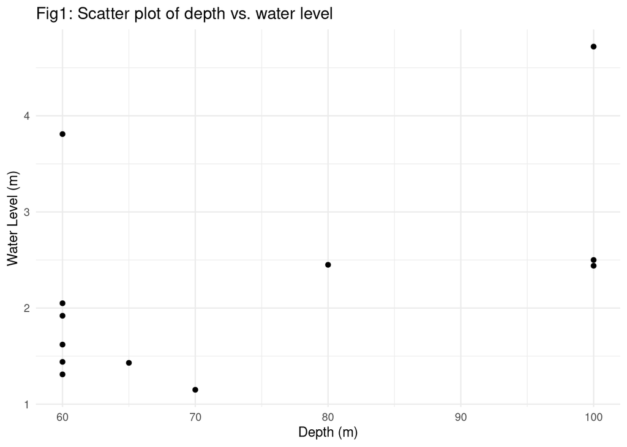

```r
#load the required packages
library(ggplot2)

## Scatter Plot
#| label: fig-scatter
#| fig-cap: "Scatter plot of depth vs. water level"
scatter_plot <- transformed_data |>
  ggplot(aes(x = depth_m, y = water_level_m)) +
  geom_point() +
  labs(title = "Fig1: Scatter plot of depth vs. water level",
       x = "Depth (m)",
       y = "Water Level (m)") +
  theme_minimal()

# Display the scatter plot
print(scatter_plot)
```

```r
# Save the scatter plot as a .png file
ggsave("Fig_1_scatter_plot.png",
       plot = scatter_plot,
       width = 6,
       height = 4,
       units = "in",
       dpi = 300)
```

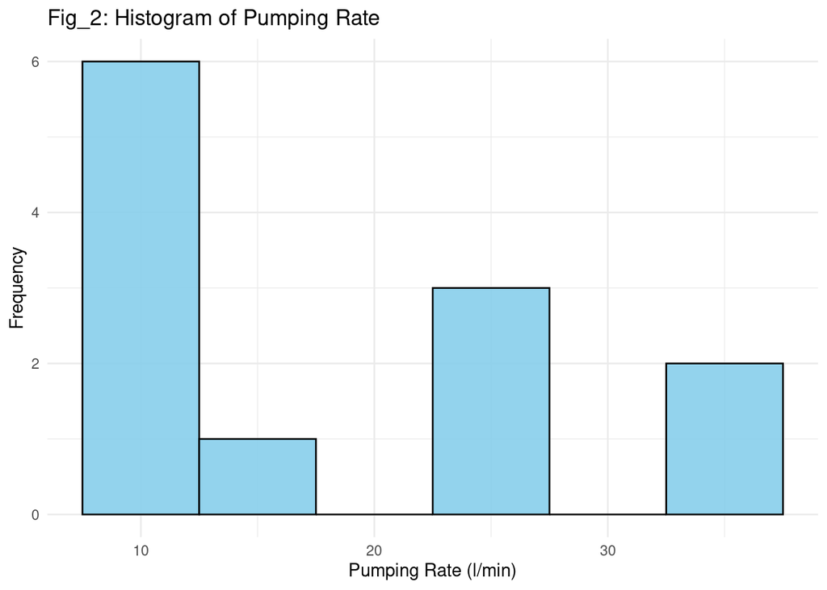

```r
#load the required packages
library(ggplot2)

#| label: fig-histogram-pumprate
#| fig-cap: "Histogram of Pumping Rate"
histogram <- transformed_data |>
ggplot(aes(x = pump_rate_l_min)) +
geom_histogram(binwidth = 5, fill = "skyblue", color = "black", alpha = 0.9) +
labs(title = "Fig_2: Histogram of Pumping Rate", x = "Pumping Rate (l/min)", y = "Frequency") +
theme_minimal()

# display the histogram
print(histogram)
```

```r
#Save the plot as a .png file
ggsave("histogram.png",
       plot = histogram,
       width = 6,
       height = 4,
       units = "in",
       dpi = 300)
```

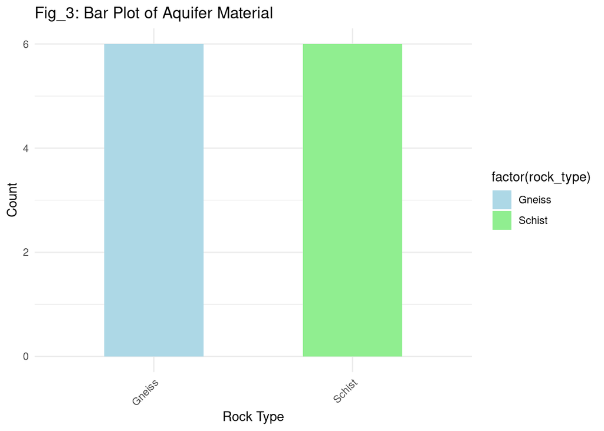

```r
#load package
library(ggplot2)

#| label: fig-bar-rocktype
#| fig-cap: "Bar Plot of Aquifer Material"
bar_plot <- transformed_data |>
ggplot(aes(x = factor(rock_type))) +
geom_bar(aes(fill = factor(rock_type)), width = 0.5) +
labs(title = "Fig_3: Bar Plot of Aquifer Material", x = "Rock Type", y = "Count") +
theme_minimal() +
theme(axis.text.x = element_text(angle = 45, hjust = 1)) +
scale_fill_manual(values = c("lightblue", "lightgreen", "lightpink", "lightyellow"))

# Display the bar plot
print(bar_plot)
```

```r
#Save the plot as a .png file
ggsave("bar_plot.png", plot = bar_plot, width = 6, height = 4, units = "in", dpi = 300)
```

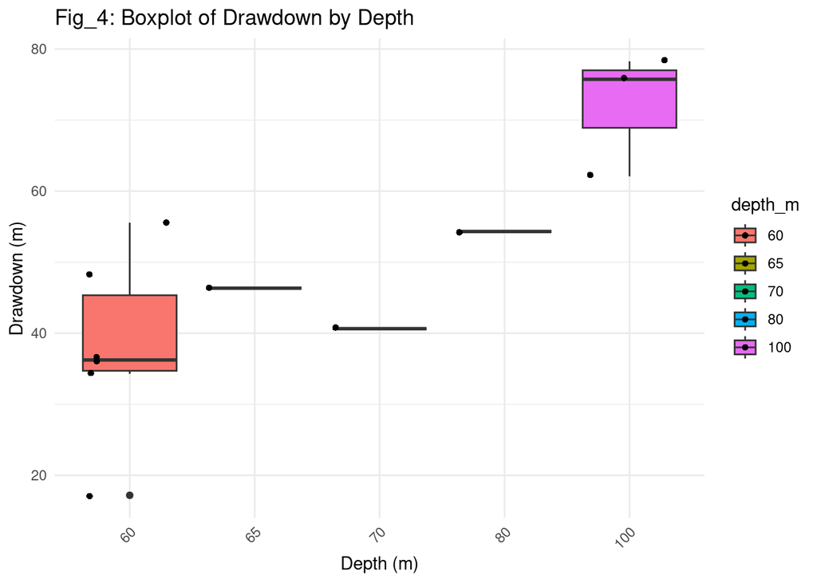

```r
#load package
library(ggplot2)

#| label: fig-box-drawdown
#| fig-cap: "Boxplot of Drawdown by Depth"
transformed_data$depth_m <- as.factor(transformed_data$depth_m)
box_plot <- transformed_data |>
ggplot(aes(x = depth_m, y = drawdown_m, fill = depth_m)) +
geom_boxplot() +
geom_jitter(shape = 16, position = position_jitter(0.4), color = "black", alpha = 1.5) +
labs(title = "Fig_4: Boxplot of Drawdown by Depth", x = "Depth (m)", y = "Drawdown (m)") +
theme_minimal() +
theme(axis.text.x = element_text(angle = 45, hjust = 1))

# Display the box plot
print(box_plot)
```

```r
#Save the plot as a .png file
ggsave("box_plot.png", plot = box_plot, width = 6, height = 4, units = "in", dpi = 300)
```

#### 3.4.2.6. Data Orgainzation

```r
glimpse(transformed_data)
```

```
Rows: 12
Columns: 10
$ date                  <dttm> 2001-01-01, 2001-01-01, 2001-01-01, 2001-01-01,…
$ region                <chr> "Greater Accra", "Greater Accra", "Greater Accra…
$ community             <chr> "Agbleazaa", "La Court", "Okpoi Gonno", "Osu Ako…
$ depth_m               <fct> 100, 100, 60, 100, 60, 60, 60, 80, 65, 60, 60, 70
$ water_level_m         <dbl> 4.72, 2.50, 1.92, 2.44, 1.62, 1.31, 3.81, 2.45, …
$ pump_rate_l_min       <dbl> 10, 10, 25, 11, 11, 35, 35, 25, 10, 10, 15, 25
$ drawdown_m            <dbl> 62.08, 78.27, 17.19, 75.74, 48.30, 36.49, 34.29,…
$ spec_capacity_m2_day  <dbl> 0.23, 0.18, 2.09, 0.21, 0.33, 1.38, 1.47, 1.55, …
$ transmissivity_m3_day <dbl> 0.25, 0.11, 1.27, 0.16, 0.52, 0.80, 0.52, 0.60, …
$ rock_type             <chr> "Schist", "Schist", "Gneiss", "Schist", "Gneiss"…
```

```r
transformed_data |>
  count(community)
```

```
# A tibble: 12 × 2
   community                 n
   <chr>                 <int>
 1 Adum                      1
 2 Agbleazaa                 1
 3 Amekom                    1
 4 Ayeduase                  1
 5 Klagon Ayigbekope         1
 6 Klagon Central Mosque     1
 7 Klagon Sankara            1
 8 Kotei                     1
 9 La Court                  1
10 La Lamptey George         1
11 Okpoi Gonno               1
12 Osu Akoadjei              1
```

```r
levels_rock_type <- c("Schist", "Gneiss")

levels_community <- c("Agbleazaa",
                     "La Court",
                     "Okpoi Gonno",
                     "La Lamptey George",
                     "Klagon Sankara",
                     "Klagon Central Mosque",
                     "Klagon AyigbeKope",
                     "Kotei",
                     "Ayeduase",
                     "Amekon",
                     "Adum")


transformed_data_lvl <- transformed_data |>
  mutate(community = factor(community, levels = levels_community),
         rock_type = factor(rock_type, levels = levels_rock_type),
         region = factor(region, levels = c("Greater Accra", "Ashanti"))
         )
```

#### 3.4.2.7. Data Pivoting

```r
transformed_data_long <- transformed_data |>
  mutate(depth_m = as.numeric(as.character(depth_m))) |>
  pivot_longer(
    cols = c(depth_m:transmissivity_m3_day),
    names_to = "measurement_variable",
    values_to = "value"
    )
```

#### 3.4.2.8. Analysis of ready-processed data (dictionary.csv)

```r
# Load necessary libraries
library(tidyverse)

# Import dictionary.csv
raw_data <- read_csv(here::here("data/processed/dictionary.csv"))

# Create a data frame for dictionary.csv
dictionary_data <- data.frame(
  variable_name = c("date", "region", "community", "depth", "water_level", "pump_rate", "drawdown", "material"),
  description = c("date_of_observation", "region_of_observation", "community_of_observation", "depth_of_well", "static_water_level", "pumping_rate", "drawdown_of_water_level", "material_of_aquifer"))

# Write the data frame to dictionary.csv
write_csv(dictionary_data, "dictionary_data")


# Add another column with names
new_dictionary_data <- dictionary_data |>
  mutate(units = c("NA", "NA", "NA", "m", "m", "l/min", "m", "NA"))


# Display the updated dictionary
print(new_dictionary_data)
```

```
  variable_name              description units
1          date      date_of_observation    NA
2        region    region_of_observation    NA
3     community community_of_observation    NA
4         depth            depth_of_well     m
5   water_level       static_water_level     m
6     pump_rate             pumping_rate l/min
7      drawdown  drawdown_of_water_level     m
8      material      material_of_aquifer    NA
```

```r
# Pivot the data
pivoted_data <- new_dictionary_data |>
  pivot_wider(names_from = variable_name, values_from = c(description, units), names_sep = "_")

new_pivoted_data <- data.frame(
  date_of_observation = c("2001-01-01", "2001-01-02", "2001-01-03"),
  region_of_observation = c("Greater_Accra", "Greater_Accra", "Ashanti"),
  community_of_observation = c("Agbleazaa", "La_Court", "Kotei"),
  depth_of_well_m = c(10, 15, 20),
  static_water_level_m = c(5, 8, 12),
  pumping_rate_l_min = c(20, 25, 30),
  drawdown_of_water_level_m = c(2, 3, 4),
  material_of_aquifer = c("Schist", "Gneiss", "Schist"))

# Data preprocessing
processed_data <- new_pivoted_data

# Select relevant columns for analysis
processed_data |>
  select(
    date_of_observation,
    region_of_observation,
    community_of_observation,
    depth_of_well_m,
    static_water_level_m,
    pumping_rate_l_min,
    drawdown_of_water_level_m,
    material_of_aquifer
  )
```

```
  date_of_observation region_of_observation community_of_observation
1          2001-01-01         Greater_Accra                Agbleazaa
2          2001-01-02         Greater_Accra                 La_Court
3          2001-01-03               Ashanti                    Kotei
  depth_of_well_m static_water_level_m pumping_rate_l_min
1              10                    5                 20
2              15                    8                 25
3              20                   12                 30
  drawdown_of_water_level_m material_of_aquifer
1                         2              Schist
2                         3              Gneiss
3                         4              Schist
```

```r
# Load the 'here' package
library(here)
library(readr)


# Generate the path using here()
new_processed_data <- here("data", "processed", "processed_data.csv")

# Ensure the directory exists
if (!dir.exists(dirname(new_processed_data))) {
  dir.create(dirname(new_processed_data), recursive = TRUE)
}


# Write the CSV file using here()
readr::write_csv(processed_data, new_processed_data)
```

# 4. Results and Discussion

## 4.1. Hydrogeological Profiling

### 4.1.1. Statistical Overview of Aquifer Features

The thorough examination of borehole data in this study revealed intricate statistical patterns that shed light on key aquifer characteristics, including depth, static water levels, and geological composition. These parameters are pivotal in understanding the complex dynamics of subsurface water systems. The depth of boreholes provided insights into the vertical extent of aquifers, indicating potential water storage capacities. Static water levels offered crucial information about the water table’s position, influencing the accessibility and sustainability of groundwater resources. The geological composition, revealed through the analysis of borehole data, was a fundamental factor influencing the permeability and overall hydrogeological behavior of aquifers.

To present these findings comprehensively, the study employed statistical tools such as histograms and box plots. Histograms provided a visual representation of the distribution of aquifer characteristics, offering a clear overview of the frequency and intensity of specific values within each parameter. Box plots further enhanced this understanding by illustrating the central tendency, spread, and potential outliers in the dataset. Together, these graphical representations served to unveil the diverse subsurface landscape, allowing researchers and stakeholders to discern patterns, anomalies, and variations in aquifer properties across the study area.

The use of histograms and box plots not only facilitated a detailed exploration of statistical patterns but also enhanced the interpretability of the complex borehole data. Stakeholders, including scientists, policymakers, and water resource managers, can leverage these visualizations to make informed decisions regarding groundwater utilization and sustainable water management practices. Overall, this section contributes to an understanding of the hydrogeological intricacies in the studied regions, laying the foundation for evidence-based strategies for effective groundwater resource management.

## 4.3. Geological Influence on Hydrogeological Parameters

### 4.3.1. Correlation between Aquifer Material and Hydrogeological Parameters

Conversely, Gneiss, with its alternating layers of minerals, displayed varying permeability depending on the mineralogical composition of each layer. The interplay of quartz, feldspar, and mica in gneissic formations introduces heterogeneity, affecting the conductivity of the aquifer. Gneiss formations may exhibit anisotropic behaviour, where water movement is more efficient along certain directions due to the orientation of mineral layers. This anisotropy influences the transmissivity of the aquifer, dictating the efficiency of water extraction.

### 4.3.2. Comparative Analysis of Aquifer Materials

By focusing on cross-tabulations, this study not only quantifies the relationships between aquifer materials and hydrogeological parameters but also uncovers the intricacies of how different geological compositions influence groundwater dynamics. This approach contributed to a more understanding of the hydrogeological system, providing valuable information for resource managers and policymakers striving to implement sustainable water management practices tailored to the specific geological contexts of the study regions.

## 4.4. Synthesis of Hydrogeological Concepts

### 4.4.1. Integration with Existing Literature

The synthesis of the study’s findings with established hydrogeological concepts from the literature review yielded compelling insights that both validated and challenged prevailing theories. The comparative analysis elucidates several key findings that contribute significantly to the ongoing scientific discourse in hydrogeology. Firstly, the study’s observations regarding aquifer characteristics, including depth, static water levels, and geological composition, align closely with established principles outlined in existing literature. This consistency serves to reinforce the reliability and universality of certain hydrogeological concepts, providing robust support for foundational theories.

In essence, the synthesis not only strengthens the credibility of established hydrogeological concepts but also contributes to the evolution of the field by challenging conventional thinking and presenting fresh perspectives. This dynamic interaction between empirical findings and theoretical frameworks underscores the dynamic nature of hydrogeological science and highlights the continuous need for adaptive models that incorporate site-specific variations.

## 4.5. Socio-Hydrological Realities

### 4.5.1. Quantitative Analysis of Factors Contributing to Challenges

Moreover, the dataset brings attention to deficiencies in the existing water supply systems. Quantitative indicators such as pumping rates, drawdown, and specific capacity provide insights into the operational inefficiencies and limitations of the current water supply infrastructure. These deficiencies contribute directly to challenges in maintaining a consistent and accessible water supply for the communities. As such, quantitative analysis of the dataset offers a comprehensive understanding of the multifaceted issues surrounding water access, guiding policymakers and stakeholders toward evidence-based solutions that account for the quantitative dimensions of population growth, infrastructure limitations, and water supply system deficiencies.

### 4.5.2. Qualitative Insight Through Community Engagement

The qualitative insights derived from community engagement activities play a pivotal role in enriching the understanding of socio-hydrological complexities, offering a human-centered perspective on the challenges associated with water access. Through direct interactions with community members, the study captures the lived experiences, perceptions, and concerns related to water availability. These qualitative findings transcend mere statistical data, providing a deeper comprehension of the intricate interplay between societal dynamics and hydrological factors.

Community engagement reveals narratives that contextualize the quantitative data, unraveling the socio-cultural aspects that influence water access challenges. Local perspectives on water usage patterns, traditional water management practices, and community-specific water needs emerge, painting a comprehensive picture of the intricate relationship between communities and their water resources. Additionally, qualitative insights shed light on the social implications of water scarcity, such as communal conflicts arising from limited water availability, gender-specific roles in water collection, and the impact of water-related challenges on daily livelihoods.

Furthermore, community engagement activities uncover community-driven solutions and adaptive strategies that may not be apparent through quantitative analysis alone. Understanding the socio-hydrological complexities from the viewpoint of the affected communities is integral for the formulation of inclusive and culturally sensitive water management policies. It ensures that proposed solutions resonate with local needs, fostering a more sustainable and community-centric approach to addressing water access challenges. In essence, qualitative insights gleaned from community engagement activities contribute a human-centric dimension to the study, enhancing the overall understanding of the socio-hydrological landscape and guiding the development of holistic and people-oriented water resource management strategies.

## 4.6. Shaping Inclusive Water Policies

### 4.6.1. Interdisciplinary Collaboration in Hydrogeological Research

Reflecting on the collaborative framework among hydrogeologists, geologists, environmental scientists, and water engineers illuminates the synergies that collectively contribute to a holistic understanding of the hydrogeological system. This collaborative approach harnesses the diverse expertise of each discipline, fostering a comprehensive and integrated perspective on the complex dynamics of groundwater resources. Hydrogeologists bring specialized knowledge in groundwater flow, aquifer characteristics, and pumping test methodologies. Geologists contribute insights into the geological formations, identifying subsurface structures and their impact on water movement. Environmental scientists provide crucial input on the ecological aspects, including the potential impacts of groundwater extraction on ecosystems.

The collaboration extends to water engineers who bring practical insights into water infrastructure design, distribution, and management. By combining these diverse perspectives, the collaborative framework ensures that the study transcends disciplinary boundaries, addressing the hydrogeological system in its entirety. This section emphasizes how the synergies among experts from different fields enhance the quality and depth of the research findings. For instance, the integration of geological insights with hydrogeological data allows for a more accurate interpretation of aquifer properties, while the inclusion of environmental considerations ensures a balanced understanding of the broader ecological implications of groundwater dynamics.

This collaborative synergy not only strengthens the scientific rigor of the study but also has practical implications for the development of sustainable water resource management strategies. It highlights the importance of interdisciplinary collaboration in addressing complex hydrogeological challenges, reinforcing the notion that a holistic approach is essential for effective decision-making and long-term environmental stewardship.

### 4.6.2. Stakeholder Engagement Outcomes

Insights garnered from stakeholder engagement activities, encompassing local communities, governmental bodies, and non-governmental organizations, play a pivotal role in shaping inclusive and sustainable water policies. By actively involving diverse stakeholders, this research embraces a participatory approach that recognizes the multi-faceted nature of water resource management. The engagement with local communities ensures that their voices, needs, and concerns become integral components of the policymaking process. Governmental bodies contribute regulatory perspectives, aligning the research outcomes with existing policies and legal frameworks, while non-governmental organizations bring advocacy and implementation expertise.

The practical implications of these stakeholder insights are profound, extending beyond the academic realm into the formulation of tangible and adaptive water policies. This section delves into how the collaborative inputs from stakeholders inform the development of policies that are not only grounded in scientific findings but are also contextually relevant and socially sensitive. For instance, community-specific water access challenges identified through engagement activities may prompt targeted interventions, such as the improvement of local infrastructure or the implementation of community-led water conservation initiatives.

Furthermore, the exploration of practical implications addresses the integration of research outcomes into broader water resource management strategies. It assesses how stakeholder-driven insights influence decision-making processes, leading to the establishment of adaptive policies capable of addressing emerging challenges. The emphasis is on creating a framework that promotes inclusivity, sustainability, and resilience in the face of evolving hydrogeological dynamics and community needs.

In essence, this section serves as a bridge between academic research and actionable policies, illustrating how stakeholder engagement enriches the policymaking process. It highlights the transformative potential of research outcomes, emphasizing their direct impact on the real-world management of water resources, thereby contributing to the broader goal of achieving inclusive, sustainable, and community-responsive water policies.

# 5. Conclusion

## References

Ansong, A. (2017). Corporate social responsibility and firm performance of ghanaian SMEs: The role of stakeholder engagement. *Cogent Business & Management*, *4*(1), 1333704.

Asare, V.-D. S., & Menyeh, A. (2013). Geo-electrical investigation of groundwater resources and aquifer characteristics in some small communities in the gushiegu and karaga districts of northern ghana. *International Journal of Scientific & Technology Research*, *2*, 25–35.

Boampong, M. S., Boakye-Danquah, J., Boafo, Y. A., Appiagyei, K., Tweneboah-Koduah, D., & Antwi, E. K. (2024). Experiences of inequality in international collaborative research–perspectives from environmental and sustainability scholars from ghana, west africa. *Environmental Science & Policy*, *152*, 103661.

Dorleku, M., Gibrilla, A., Ganyaglo, S., Duah, A., Osae, S., & Essumang, D. (2023). Spatio-temporal variation of groundwater chemistry in the upper oti basin of ghana. *Environmental Monitoring and Assessment*, *195*(1), 246.

Fielmua, N. (2011). The role of the community ownership and management strategy towards sustainable access to water in ghana (a case of nadowli district). *Journal of Sustainable Development*, *4*(3), 174.

Owusu-Addo, E., Cross, R., & Sarfo-Mensah, P. (2017). Evidence-based practice in local public health service in ghana. *Critical Public Health*, *27*(1), 125–138.

Yidana, S. M., Ophori, D., & Banoeng-Yakubo, B. (2008). Hydrogeological and hydrochemical characterization of the voltaian basin: The afram plains area, ghana. *Environmental Geology*, *53*, 1213–1223.